# Application of Bootstrap samples in Random Forest

```python
import numpy as np
from sklearn.datasets import load_boston
from sklearn.metrics import mean_squared_error
```

Load the boston house dataset

```python
boston = load_boston()
x=boston.data #independent variables
y=boston.target #target variable
```

```python
x.shape
```

```
(506, 13)
```

### Task: 1

**Step 1 Creating samples:** Randomly create 30 samples from the whole boston data points.

1. Creating each sample: Consider any random 303(60% of 506) data points from whole data set and then replicate any 203 points from the sampled points
2. Ex: For better understanding of this procedure lets check this examples, assume we have 10 data points [1,2,3,4,5,6,7,8,9,10], first we take 6 data points randomly consider we have selected [4, 5, 7, 8, 9, 3] now we will replciate 4 points from [4, 5, 7, 8, 9, 3], consder they are [5, 8, 3,7] so our final sample will be [4, 5, 7, 8, 9, 3, 5, 8, 3,7]
3. we create 30 samples like this
4. Note that as a part of the Bagging when you are taking the random samples make sure each of the sample will have different set of columns
5. Ex: assume we have 10 columns for the first sample we will select [3, 4, 5, 9, 1, 2] and for the second sample [7, 9, 1, 4, 5, 6, 2] and so on...
6. Make sure each sample will have atleast 3 feautres/columns/attributes

**Step 2 Building High Variance Models on each of the sample and finding train MSE value:** Build a DecisionTreeRegressor on each of the sample.

1. Build a regression trees on each of 30 samples.
2. computed the predicted values of each data point(506 data points) in your corpus.
3. predicted house price of $i^{th}$ data point $y^{i}_{pred} = \frac{1}{30}\sum_{k=1}^{30}(\text{predicted value of } x^{i} \text{ with } k^{th} \text{ model})$.
4. Now calculate the $MSE = \frac{1}{506}\sum_{i=1}^{506}(y^{i} - y^{i}_{pred})^{2}$.

**Step 3 Calculating the OOB score :**

1. Computed the predicted values of each data point(506 data points) in your corpus.
2. Predicted house price of $i^{th}$ data point $y^{i}_{pred} = \frac{1}{k}\sum_{\text{k= model which was buit on samples not included } x^{i}}(\text{predicted value of } x^{i} \text{ with } k^{th} \text{ model})$.
3. Now calculate the $OOB Score = \frac{1}{506}\sum_{i=1}^{506}(y^{i} - y^{i}_{pred})^{2}$.

### Task: 2

```
Computing CI of OOB Score and Train MSE

 Repeat Task 1 for 35 times, and for each iteration store the Train MSE and OOB score
 After this we will have 35 Train MSE values and 35 OOB scores
 using these 35 values (assume like a sample) find the confidence intravels of MSE and OOB Score
 you need to report CI of MSE and CI of OOB Score
 Note: Refer the Central_Limit_theorem.ipynb to check how to find the confidence intravel
```

### Task: 3

```
Given a single query point predict the price of house.

Consider xq= [0.18,20.0,5.00,0.0,0.421,5.60,72.2,7.95,7.0,30.0,19.1,372.13,18.60] Predict the house price for this point as mentioned in the step 2 of Task 1.
```

```python
import random

row_indices_iob = []
row_indices_oob = []
col_indices     = []

for i in range(30):
    iob_indices = np.random.choice(range(506),303)
    iob_indices = np.hstack([iob_indices,np.random.choice(iob_indices,size=203)])
    col_index = np.array(random.sample(range(13),random.randint(3,13)))
    row_indices_iob.append(iob_indices)
    col_indices.append(col_index)
    oob_indices = np.setdiff1d(range(506),iob_indices)
    row_indices_oob.append(oob_indices)
print(row_indices_iob[29].shape)
print(row_indices_oob[29].shape)
print(col_indices[29].shape)
```

```
(506,)
(273,)
(12,)
```

```python
from sklearn.tree import DecisionTreeRegressor
Y_pred = [0 for i in range(506)]
for i in range(30):
    clf = DecisionTreeRegressor()
    X_train = x[row_indices_iob[i][:,None],col_indices[i]]
    Y_train = y[row_indices_iob[i]]
    clf.fit(X_train,Y_train)
    Y_pred += clf.predict(x[:,col_indices[i]])
Y_pred = Y_pred/30

errors = (y-Y_pred)**2
MSE = errors.sum()/506
print(MSE)
```

```
3.974955773336635
```

```python
Y_pred_OOB = [0 for i in range(506)]
Ks = [0 for i in range(506)]

for i in range(30):
    k = 0
    clf = DecisionTreeRegressor()
    X_train = x[row_indices_iob[i][:,None],col_indices[i]]
    Y_train = y[row_indices_iob[i]]
    clf.fit(X_train,Y_train)

    for j in range(506):
        if j not in row_indices_iob[i]:
            Ks[j] += 1
            Y_pred_OOB[k] += clf.predict(x[j,col_indices[i]].reshape(1,-1)).item()
        k += 1

Y_pred_OOB = [x/y for x,y in zip(Y_pred_OOB,Ks)]

errors_OOB = (y-Y_pred_OOB)**2
OOB = errors_OOB.sum()/506
print(OOB)
```

```
11.69163972555204
```

### Task 2

```python
MSEs = []
OOBs = []
for _ in range(35):
    row_indices_iob = []
    row_indices_oob = []
    col_indices     = []

    for i in range(30):
        iob_indices = np.random.choice(range(506),303)
        iob_indices = np.hstack([iob_indices,np.random.choice(iob_indices,size=203)])
        col_index = np.array(random.sample(range(13),random.randint(3,13)))
        row_indices_iob.append(iob_indices)
        col_indices.append(col_index)
        oob_indices = np.setdiff1d(range(506),iob_indices)
        row_indices_oob.append(oob_indices)

    Y_pred = [0 for i in range(506)]
    for i in range(30):
        clf = DecisionTreeRegressor()
        X_train = x[row_indices_iob[i][:,None],col_indices[i]]
        Y_train = y[row_indices_iob[i]]
        clf.fit(X_train,Y_train)
        Y_pred += clf.predict(x[:,col_indices[i]])
    Y_pred = Y_pred/30

    errors = (y-Y_pred)**2
    MSE = errors.sum()/506
    MSEs.append(MSE)

    Y_pred_OOB = [0 for i in range(506)]
    Ks = [0 for i in range(506)]

    for i in range(30):
        k = 0
        clf = DecisionTreeRegressor()
        X_train = x[row_indices_iob[i][:,None],col_indices[i]]
        Y_train = y[row_indices_iob[i]]
        clf.fit(X_train,Y_train)

        for j in range(506):
            if j not in row_indices_iob[i]:
                Ks[j] += 1
                Y_pred_OOB[k] += clf.predict(x[j,col_indices[i]].reshape(1,-1)).item()
            k += 1

    Y_pred_OOB = [x/y for x,y in zip(Y_pred_OOB,Ks)]

    errors_OOB = (y-Y_pred_OOB)**2
    OOB = errors_OOB.sum()/506
    OOBs.append(OOB)

print(MSEs)
print('='*120)
print(OOBs)
```

```
[3.8472391580207597, 4.423723355818459, 4.674006739780048, 4.627198883931476, 4.137153248508573, 4.803236730456621, 4.435555248665485, 4.500476470394291, 4.215775773973344, 4.393658868006697, 4.404003390559688, 3.8481509290725167, 3.9115398479907797, 4.360412047485164, 4.480441525906438, 4.167973277…
========================================================================================================================
[12.289036235714564, 14.469099649717203, 15.6610961172924, 15.074464357196256, 13.712702361193076, 13.741634684940339, 13.757811911671507, 13.607515571375357, 13.334661527442684, 14.076942749254597, 14.122575040214967, 13.322618315083716, 12.915276541617825, 12.87967277513743, 14.18989103157671, 13.…
```

```python
#calculating 95% confidence interval
no_of_samples = 200
no_of_bins = 10

from prettytable import PrettyTable
MSE_means = []
table = PrettyTable()
table = PrettyTable(["#samples", "Sample Size", "Sample mean", "Sample std","Left C.I","Right C.I"])
for i in range(no_of_samples):
    sample=[MSEs[i] for i in random.choices(range(35),k=10)]
    sample_mean = np.mean(sample)
    MSE_means.append(sample_mean)
    sample_std =  np.std(sample)
    sample_size = len(sample)
    # here we are using sample standard deviation instead of population standard deviation
    left_limit  = np.round(sample_mean - 2*(sample_std/np.sqrt(sample_size)), 3)
    right_limit = np.round(sample_mean + 2*(sample_std/np.sqrt(sample_size)), 3)
    row = []
    row.append(i+1)
    row.append(sample_size)
    row.append(sample_mean)
    row.append(sample_std)
    row.append(left_limit)
    row.append(right_limit)
    table.add_row(row)
print('======================== Calculation Interval Calculations for MSE =========================')
print(table)
```

```
======================== Calculation Interval Calculations for MSE =========================
+----------+-------------+--------------------+---------------------+----------+-----------+
| #samples | Sample Size |    Sample mean     |      Sample std     | Left C.I | Right C.I |
+----------+-------------+--------------------+---------------------+----------+-----------+
|    1     |      10     | 4.075129360867921  |  0.5244911977141258 |  3.743   |   4.407   |
|    2     |      10     | 4.187460691531364  | 0.46223527503691647 |  3.895   |    4.48   |
|    3     |      10     | 4.361574390407271  | 0.22383955406118727 |   4.22   |   4.503   |
|    4     |      10     | 4.393131192833627  | 0.38473488931167044 |   4.15   |   4.636   |
|    5     |      10     | 4.440739067359237  | 0.46719209803288103 |  4.145   |   4.736   |
|    6     |      10     | 4.3318684759251935 |  0.4333555910466703 |  4.058   |   4.606   |
|    7     |      10     | 4.411318698917131  |  0.4571887688236746 |  4.122   |    4.7    |
|    8     |      10     | 4.341467418944108  | 0.45830694294967156 |  4.052   |   4.631   |
|    9     |      10     | 4.235089179698016  |  0.2582658943463807 |  4.072   |   4.398   |
|    10    |      10     | 4.381665165354279  | 0.21956577994476403 |  4.243   |   4.521   |
|    11    |      10     | 4.425287091976797  |  0.4550097216228392 |  4.138   |   4.713   |
|    12    |      10     | 4.075441276584313  |  0.5184280702463353 |  3.748   |   4.403   |
|    13    |      10     | 4.355671533404453  | 0.43138851259058686 |  4.083   |   4.629   |
|    14    |      10     | 4.199941270111568  |  0.3504781695306132 |  3.978   |   4.422   |
|    15    |      10     | 4.072262482449671  |  0.2710351262939642 |  3.901   |   4.244   |
|    16    |      10     | 4.242347578369914  |  0.376829737015435  |  4.004   |   4.481   |
|    17    |      10     |  4.44583742215536  | 0.43941975530650623 |  4.168   |   4.724   |
|    18    |      10     | 4.048012584370863  | 0.41711945554545626 |  3.784   |   4.312   |
|    19    |      10     | 4.195655880725784  |  0.5307218310217404 |   3.86   |   4.531   |
|    20    |      10     | 4.276929184650393  |  0.3409663244586502 |  4.061   |   4.493   |
|    21    |      10     | 4.3336973239273116 |  0.5236106657488898 |  4.003   |   4.665   |
|    22    |      10     | 3.968312716241698  |  0.4389649223547913 |  3.691   |   4.246   |
|    23    |      10     | 4.431146055845599  |  0.460952351147867  |   4.14   |   4.723   |
|    24    |      10     | 4.4033297621072185 |  0.421750716941502  |  4.137   |    4.67   |
|    25    |      10     | 4.332252941786477  |  0.2970174739444613 |  4.144   |    4.52   |
|    26    |      10     |  4.36333229499304  | 0.28386450712942285 |  4.184   |   4.543   |
|    27    |      10     | 4.4410433146176675 |  0.5744357010226209 |  4.078   |   4.804   |
|    28    |      10     | 4.477089687792327  | 0.20486073566890953 |  4.348   |   4.607   |
|    29    |      10     | 4.376916894886185  |  0.5077584071838566 |  4.056   |   4.698   |
|    30    |      10     | 4.4399094054855395 |  0.3121058084517692 |  4.243   |   4.637   |
|    31    |      10     | 4.475020617038686  | 0.41778367959018037 |  4.211   |   4.739   |
|    32    |      10     | 4.273230650005795  | 0.34965781016853714 |  4.052   |   4.494   |
|    33    |      10     |  4.20156832737765  | 0.36818775287931005 |  3.969   |   4.434   |
|    34    |      10     | 4.391853748669609  | 0.24496579445750033 |  4.237   |   4.547   |
|    35    |      10     | 4.2410689867089975 | 0.35334072575310677 |  4.018   |   4.465   |
|    36    |      10     | 4.344262797362012  | 0.35479121054725193 |   4.12   |   4.569   |
```

[output cut: 150 more lines]

```
|   187    |      10     | 4.251849402190762  |  0.3569200477767188 |  4.026   |   4.478   |
|   188    |      10     | 4.204828224826241  | 0.27162316497631056 |  4.033   |   4.377   |
|   189    |      10     | 4.281516902172294  |  0.3363002761224759 |  4.069   |   4.494   |
|   190    |      10     | 4.518863210874611  |  0.5602834435404571 |  4.165   |   4.873   |
|   191    |      10     | 4.5059389683749185 | 0.18983727165801126 |  4.386   |   4.626   |
|   192    |      10     | 4.343557571879518  |  0.3314390514431859 |  4.134   |   4.553   |
|   193    |      10     | 4.348464434287419  | 0.47307307013158073 |  4.049   |   4.648   |
|   194    |      10     | 4.285470586869936  |  0.3291090695319485 |  4.077   |   4.494   |
|   195    |      10     | 4.278376625730462  |  0.5202283563087551 |  3.949   |   4.607   |
|   196    |      10     | 4.151219238587083  |  0.3325883621346217 |  3.941   |   4.362   |
|   197    |      10     | 4.147584191973595  |  0.4467574833938899 |  3.865   |    4.43   |
|   198    |      10     | 4.141113791827148  | 0.22420372695307902 |  3.999   |   4.283   |
|   199    |      10     | 4.337319583425104  |  0.2765387439886831 |  4.162   |   4.512   |
|   200    |      10     | 4.322703530285968  |  0.2979363155369192 |  4.134   |   4.511   |
+----------+-------------+--------------------+---------------------+----------+-----------+
```

```python
mean_of_means = np.mean(MSE_means)
std_dev_of_means = np.mean(sample_std)
mean_Left_CI = np.round(mean_of_means - 2*(std_dev_of_means/np.sqrt(10)), 3)
mean_Right_CI = np.round(mean_of_means + 2*(std_dev_of_means/np.sqrt(10)), 3)

print('Mean of Means: ',mean_of_means)
print('Mean Std-Dev : ',std_dev_of_means)
print('Mean Left CI : ',mean_Left_CI)
print('Mean Right CI: ',mean_Right_CI)
```

```
Mean of Means:  4.301133940773954
Mean Std-Dev :  0.2979363155369192
Mean Left CI :  4.113
Mean Right CI:  4.49
```

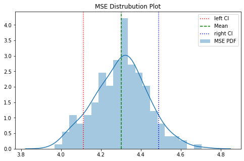

```python
import seaborn as sns
import matplotlib.pyplot as plt
plt.figure(figsize=(8,5))
sns.distplot(MSE_means, bins=no_of_samples//no_of_bins)
plt.axvline(x=mean_Left_CI, c='red',ls=':')
plt.axvline(x=mean_of_means, c='green',ls='--')
plt.axvline(x=mean_Right_CI, c='blue',ls=':')
plt.legend(['left CI','Mean','right CI','MSE PDF'])
plt.title('MSE Distrubution Plot')
plt.show()
```

```python
#calculating 95% confidence interval
from prettytable import PrettyTable
OOB_means = []
table = PrettyTable()
table = PrettyTable(["#samples", "Sample Size", "Sample mean", "Sample std","Left C.I","Right C.I"])
for i in range(no_of_samples):
    sample=[OOBs[i] for i in random.choices(range(35),k=10)]
    sample_mean = np.mean(sample)
    OOB_means.append(sample_mean)
    sample_std =  np.std(sample)
    sample_size = len(sample)
    # here we are using sample standard deviation instead of population standard deviation
    left_limit  = np.round(sample_mean - 2*(sample_std/np.sqrt(sample_size)), 3)
    right_limit = np.round(sample_mean + 2*(sample_std/np.sqrt(sample_size)), 3)
    row = []
    row.append(i+1)
    row.append(sample_size)
    row.append(sample_mean)
    row.append(sample_std)
    row.append(left_limit)
    row.append(right_limit)
    table.add_row(row)
print('======================== Calculation Interval Calculations for OOB =========================')
print(table)
```

```
======================== Calculation Interval Calculations for OOB =========================
+----------+-------------+--------------------+---------------------+----------+-----------+
| #samples | Sample Size |    Sample mean     |      Sample std     | Left C.I | Right C.I |
+----------+-------------+--------------------+---------------------+----------+-----------+
|    1     |      10     | 13.112979626691521 | 0.46627438692820333 |  12.818  |   13.408  |
|    2     |      10     | 13.881885781992633 |  0.515476379021685  |  13.556  |   14.208  |
|    3     |      10     | 13.507101877443228 |  1.1323713960397965 |  12.791  |   14.223  |
|    4     |      10     | 13.307519521149732 |  0.979608799702532  |  12.688  |   13.927  |
|    5     |      10     | 13.974850434183608 |  0.9159545402995406 |  13.396  |   14.554  |
|    6     |      10     | 13.558455922888545 |  1.104545393753663  |  12.86   |   14.257  |
|    7     |      10     | 14.004380945580374 |  1.1102809955882513 |  13.302  |   14.707  |
|    8     |      10     | 13.980834670510115 |  0.9114667784082296 |  13.404  |   14.557  |
|    9     |      10     | 14.219883281506963 |  1.0733858848824889 |  13.541  |   14.899  |
|    10    |      10     | 13.205576100996135 |  0.5326396099100604 |  12.869  |   13.542  |
|    11    |      10     | 13.443557085146988 |  0.7331691095079382 |  12.98   |   13.907  |
|    12    |      10     | 13.962974892726038 |  1.1419242102185279 |  13.241  |   14.685  |
|    13    |      10     | 13.515288373706118 |  0.9590374759838882 |  12.909  |   14.122  |
|    14    |      10     | 13.807725307134735 |  0.641398320560128  |  13.402  |   14.213  |
|    15    |      10     | 13.952820133900364 |  0.6951183256741179 |  13.513  |   14.392  |
|    16    |      10     | 13.675005317561567 |  0.4565835227230701 |  13.386  |   13.964  |
|    17    |      10     | 14.07702517180049  |  1.3296857015037944 |  13.236  |   14.918  |
|    18    |      10     | 13.772202399844364 |  0.7679411581879485 |  13.287  |   14.258  |
|    19    |      10     | 13.472387437823306 |  1.050651591376646  |  12.808  |   14.137  |
|    20    |      10     | 13.712766917981748 |  1.1579503789512582 |  12.98   |   14.445  |
|    21    |      10     | 13.48706771855198  |  1.2240142739050242 |  12.713  |   14.261  |
|    22    |      10     | 13.414716843522465 |  0.580635895181133  |  13.047  |   13.782  |
|    23    |      10     | 13.13362506809934  | 0.44657112587946163 |  12.851  |   13.416  |
|    24    |      10     | 13.804055814488208 |  0.9514774640168396 |  13.202  |   14.406  |
|    25    |      10     | 13.79959537408914  |  0.6579514896188957 |  13.383  |   14.216  |
|    26    |      10     | 13.659560472550734 |  0.880051397776119  |  13.103  |   14.216  |
|    27    |      10     | 13.503395488362225 |  0.8214703676029353 |  12.984  |   14.023  |
|    28    |      10     | 13.614104685898923 |  1.036583557096561  |  12.959  |   14.27   |
|    29    |      10     | 13.543761433985825 |  0.7371830415067259 |  13.078  |   14.01   |
|    30    |      10     | 13.722639284292498 |  1.1836935974849756 |  12.974  |   14.471  |
|    31    |      10     | 13.494188138151681 |  0.9956379886255069 |  12.864  |   14.124  |
|    32    |      10     | 13.343774396477155 |  0.680568622872209  |  12.913  |   13.774  |
|    33    |      10     | 13.768574341379766 |  0.6929589071955642 |  13.33   |   14.207  |
|    34    |      10     | 13.749509449324592 |  1.099418053404586  |  13.054  |   14.445  |
|    35    |      10     | 13.620858223956409 |  0.6344254501869839 |  13.22   |   14.022  |
|    36    |      10     | 13.636067631449638 |  0.5940829584427557 |  13.26   |   14.012  |
```

[output cut: 150 more lines]

```
|   187    |      10     | 13.66178728118432  |  0.7737536843510621 |  13.172  |   14.151  |
|   188    |      10     | 13.506365890209404 |  0.5387222063792582 |  13.166  |   13.847  |
|   189    |      10     | 13.575429731386057 |  0.8308120876699266 |  13.05   |   14.101  |
|   190    |      10     | 13.430939646269556 | 0.34702536703234516 |  13.211  |   13.65   |
|   191    |      10     | 13.922142010611832 |  0.8889046471329658 |  13.36   |   14.484  |
|   192    |      10     | 13.552696070338886 |  0.9689962451802915 |  12.94   |   14.166  |
|   193    |      10     | 13.768020677965003 |  0.896589812288967  |  13.201  |   14.335  |
|   194    |      10     | 13.380863979676425 |  0.6507599122779483 |  12.969  |   13.792  |
|   195    |      10     | 14.473816142136096 |  1.0670006916408707 |  13.799  |   15.149  |
|   196    |      10     | 14.14297070671525  |  0.978616426451656  |  13.524  |   14.762  |
|   197    |      10     | 13.94942902146202  |  1.301006807035547  |  13.127  |   14.772  |
|   198    |      10     | 13.963599178341564 |  1.2000927514018709 |  13.205  |   14.723  |
|   199    |      10     | 13.263168788181748 |  0.8976918248714162 |  12.695  |   13.831  |
|   200    |      10     | 13.276618381892561 |  0.6423745739234066 |  12.87   |   13.683  |
+----------+-------------+--------------------+---------------------+----------+-----------+
```

```python
mean_of_means = np.mean(OOB_means)
std_dev_of_means = np.mean(sample_std)
mean_Left_CI = np.round(mean_of_means - 2*(std_dev_of_means/np.sqrt(10)), 3)
mean_Right_CI = np.round(mean_of_means + 2*(std_dev_of_means/np.sqrt(10)), 3)

print('Mean of Means: ',mean_of_means)
print('Mean Std-Dev : ',std_dev_of_means)
print('Mean Left CI : ',mean_Left_CI)
print('Mean Right CI: ',mean_Right_CI)
```

```
Mean of Means:  13.708229873730334
Mean Std-Dev :  0.6423745739234066
Mean Left CI :  13.302
Mean Right CI:  14.115
```

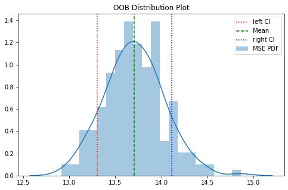

```python
plt.figure(figsize=(8,5))
sns.distplot(OOB_means, bins=no_of_samples//no_of_bins)
plt.axvline(x=mean_Left_CI, c='red',ls=':')
plt.axvline(x=mean_of_means, c='green',ls='--')
plt.axvline(x=mean_Right_CI, c='blue',ls=':')
plt.legend(['left CI','Mean','right CI','MSE PDF'])
plt.title('OOB Distribution Plot')
plt.show()
```

### Task 3

```python
xq= np.array([0.18,20.0,5.00,0.0,0.421,5.60,72.2,7.95,7.0,30.0,19.1,372.13,18.60])
Y_pred = 0
for i in range(30):
    clf = DecisionTreeRegressor()
    X_train = x[row_indices_iob[i][:,None],col_indices[i]]
    Y_train = y[row_indices_iob[i]]
    clf.fit(X_train,Y_train)
    Y_pred += clf.predict(xq[col_indices[i]].reshape(1,-1)).item()
Y_pred = Y_pred/30

print(Y_pred)
```

```
21.650000000000002
```